# 5. Gyakorlat - 1 DoF csillapított lengő kar

2021.03.08

## Feladat:

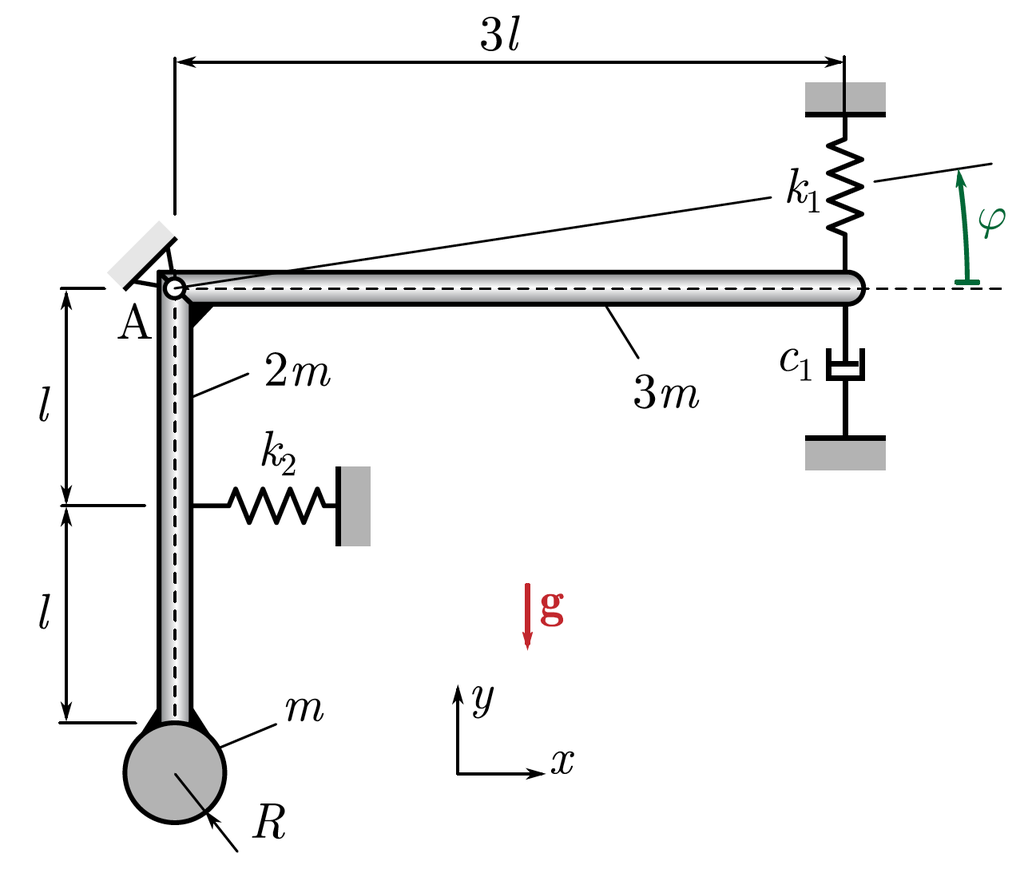

```python
from IPython.display import Image
Image(filename='gyak_5_1.png',width=500)
```

A mellékelt ábrán egy lengőkar látható, ami két különböző tömegű és hosszúságú rúdból és a hozzá csatlakozó $R$ sugarú korongból áll. A két rúd két $k_1$, illetve $k_2$ merevségű rugón és egy $c_1$ csillapítási tényezőjű csillapító elemen keresztül csatlakozik a környezetehéz. A lengőkar csak az $A$ csukló körül tud elfordulni. A mozgást leíró általános koordináta a $\varphi$ szög, melyet a vízszintes egyenestől mérünk. A lengőkar a Föld gravitációs terében helyezkedik el, egyensúlyi helyezete a $\varphi=0$ pozícióban van, ahol a $k_2$ merevségű rugó feszítetlen.

### Adatok:

| $l$ = 0,2 m | $k_1$ = 300 N/m |
| --- | --- |
| $R$ = 0,1 m | $k_2$ = 10 N/m |
| $m$ = 0,12 kg | $c_1$ = 2 Ns/m |

### Részfeladatok:

1. Írja fel a mozgásegyenletet és számítsa ki a csillapítatlan ($\omega_n$) illetve csillapított sajátfrekvenciákat ($\omega_d$), és a realtív csillapítási tényezőt ($\zeta$)!
2. Számítsa ki a kritikus csillapítási tényezőt ($c_{cr}$)!
3. Számítsa ki a $k_1$ merevségű rugóhoz tartozó maximális rugóerő értékét a következő kezdeti feltételek esetén: ($\varphi(t=0)=\varphi_0=0,01$[rad];$\dot{\varphi}(t=0)=0$[rad/s])!

## Megoldás:

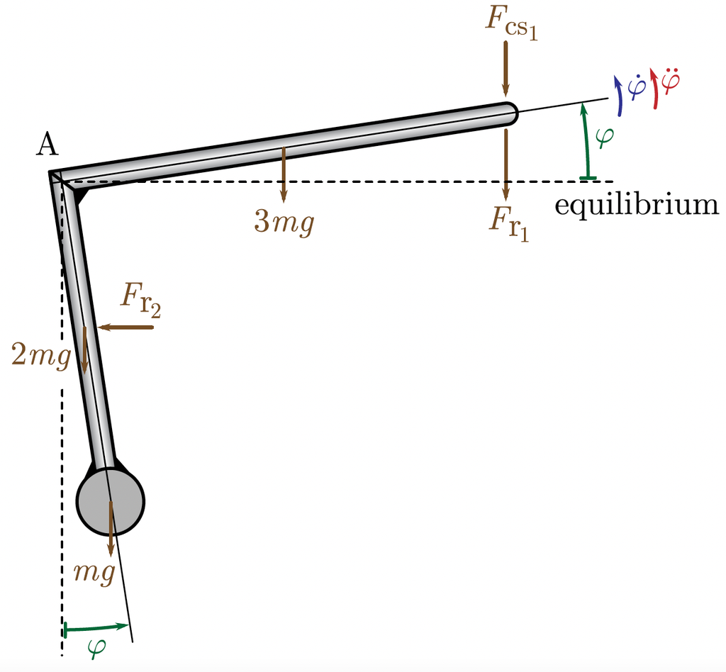

```python
from IPython.display import Image
Image(filename='gyak_5_2.png',width=500)
```

### 1. Feladat:

A fenti ábrán a lengőkar szabadtest ábrája látható az egyensúgyi helyzetből kitérített helyezetében. Egy korábbi példában (3. gyakorlat) már be lett mutatva, hogy milyen egyszerűsítéséskkel lehet élni annak érdekében, hogy linearizáljunk egy ilyen lengőrendszert. Röviden összefoglalva az egyszerűsítéseket:

- a vízszintes rúdelemre ható gravitációs erőnek nincs hatása a sajátkörfrekvenciára (viszont hatása lehet a maximális rugóerőkre);
- a rugók deformációja az egyensúlyi helyzetből mért ívhosszakkal jól közelíthetők.

A mozgásegyenlet Newton II. alapján:

\begin{equation} \dot{\mathbf{I}}=\mathbf{F}. \end{equation}

Ebből az SZTA alapján (és cos$\varphi\approx 1$, illetve a sin$\varphi\approx \varphi$ közelítéseket alkalmazva) adódik:

\begin{equation} \Theta_A\ddot{\varphi}=-F_{r,1}3l-F_{r,2}l-F_{cs,1}3l-3mg\frac{3}{2}l-2mgl\varphi-mg(2l+R)\varphi, \end{equation}

ahol a csillapításból adódó erő és a rugerők

\begin{equation} F_{cs,1}\cong c_13l\dot{\varphi}, \hspace{10pt} F_{r,1}\cong F_{r,1st}+k_13l\varphi, \hspace{10pt} F_{r,2}\cong k_2l\varphi \end{equation}

(megjegyzés: a mozgásegyenletben szerplő $-3mg\frac{3}{2}l$ tag és a $k_1$ merevségű rugó statikus deformációjáből adódó erő ($F_{r,1st}$) kiegyenlítik egymást, így kiesenek az egyenletből). Tehát a mozgásegyenlet:

\begin{equation} \Theta_A\ddot{\varphi}=-9l^2k_1\varphi-l^2k_2\varphi-9l^2c_1\dot{\varphi}-2mgl\varphi-mg(2l+R)\varphi. \end{equation}

A szerkezet tehetetlenségi nyomatékát a Steiner tétel segítségével lehet az $A$ pontra meghatározni:

\begin{equation} \Theta_A=\frac{1}{3}3ml(3l)^2+\frac{1}{3}2ml(2l)^2+\frac{1}{2}mR^2+m(2l+R)^2. \end{equation}

```python
import sympy as sp
from IPython.display import display, Math

sp.init_printing()
```

```python
l, R, m, k1, k2, c1, Θ_A, g = sp.symbols("l, R, m, k1, k2, c1, Θ_A, g", real=True)

# Készítsünk behelyettesítési listát az adatok alapján, SI-ben
adatok = [(l, 0.2), (R, 0.1), (m, 0.12), (k1, 300), (k2, 10), (c1, 2), (g, 9.81)]

# Az általános koordináta definiálása az idő függvényeként
t = sp.symbols("t",real=True, positive=True)
φ_t = sp.Function('φ')(t)

# A z tengelyre számított perdület derivált az A pontban
dΠ_Az = Θ_A*φ_t.diff(t,2)

# A z tengelyre számított nyomaték az A pontban
M_Az = -9*l**2*k1*φ_t-l**2*k2*φ_t-9*l**2*c1*φ_t.diff(t)-2*m*g*l*φ_t-m*g*(2*l+R)*φ_t

# A dinamika alapegyenlete
# (nullára rendezve)

mozgegy = dΠ_Az-M_Az
mozgegy
```

$\displaystyle 9 c_{1} l^{2} \frac{d}{d t} φ{\left(t \right)} + 2 g l m φ{\left(t \right)} + g m \left(R + 2 l\right) φ{\left(t \right)} + 9 k_{1} l^{2} φ{\left(t \right)} + k_{2} l^{2} φ{\left(t \right)} + Θ_{A} \frac{d^{2}}{d t^{2}} φ{\left(t \right)}$

```python
# Osszunk le a főegyütthatóval:
foegyutthato = mozgegy.coeff(sp.diff(φ_t,t,2))

mozgegy = (mozgegy/foegyutthato).expand().apart(φ_t)

mozgegy
```

$\displaystyle \frac{9 c_{1} l^{2} \frac{d}{d t} φ{\left(t \right)}}{Θ_{A}} + \left(\frac{R g m}{Θ_{A}} + \frac{4 g l m}{Θ_{A}} + \frac{9 k_{1} l^{2}}{Θ_{A}} + \frac{k_{2} l^{2}}{Θ_{A}}\right) φ{\left(t \right)} + \frac{d^{2}}{d t^{2}} φ{\left(t \right)}$

```python
# Írjuk be a tehetetlenségi nyomatékot
# a rúdhosszakkal és tömegekkel kifejezve
mozgegy = mozgegy.subs(Θ_A, 1/3*3*m*(3*l)**2+1/3*2*m*(2*l)**2+1/2*m*R**2+m*(2*l+R)**2)
```

```python
# A mozgásegyenletnek ebben az alakjában
# d/dt(φ(t)) együtthatója 2ζω_n -nel
# a φ(t) együtthatója pedig ω_n^2-tel egyezik meg,
# tehát mind a három kérdéses paraméter megadható.

ω_n_num = sp.sqrt((mozgegy.coeff(φ_t)).subs(adatok)).evalf(6)

ζ_num = ((mozgegy.coeff(φ_t.diff(t))).subs(adatok)/(2*ω_n_num)).evalf(4)

ω_d_num = (ω_n_num*sp.sqrt(1-ζ_num**2)).evalf(6)

display(Math('\omega_n = {}'.format(sp.latex(ω_n_num))),
        Math('\zeta = {}'.format(sp.latex(ζ_num))),
        Math('\omega_d = {}'.format(sp.latex(ω_d_num))))
# [rad/s]
# [1]
# [rad/s]
```

$\displaystyle \omega_n = 35.5523$

$\displaystyle \zeta = 0.1169$

$\displaystyle \omega_d = 35.3085$

```python
# Később még szükség lesz a csillapított frekvenciára és periódusidőre is:
T_d_num = (2*sp.pi/ω_d_num).evalf(4)

f_d_num = (ω_d_num/(2*sp.pi)).evalf(5)
display(Math('T_d = {}'.format(sp.latex(T_d_num))),
        Math('f_d = {}'.format(sp.latex(f_d_num))))

# [s]
# [1/s]
```

$\displaystyle T_d = 0.178$

$\displaystyle f_d = 5.6195$

## 2. Feladat

Kritikus csillapításról akkor beszélünk, amikor a relatív csillapítási tényező éppen 1.

```python
# A mozgásegyenletnek d/dt(φ(t)) együtthatóját kell vizsgálni
mozgegy.coeff(φ_t.diff(t)).evalf(5)
```

$\displaystyle \frac{9.0 c_{1} l^{2}}{0.5 R^{2} m + 11.667 l^{2} m + 4.0 m \left(0.5 R + l\right)^{2}}$

```python
# Ez az együttható pont 2ζω_n -nel egyenlő.
# Az így adódó egyenlet megoldásásval kapjuk
# a kritikus csillapítshoz tartozó c1 értéket:
ζ_cr = 1

# itt még nem helyettesítünk be, hanem csak kifejezzük a kritikus csillapítási együtthatót
c1_cr = sp.solve(mozgegy.coeff(φ_t.diff(t))-2*ζ_cr*ω_n_num,c1)[0]

# most már be lehet helyettesíteni
c1_cr_num = c1_cr.subs(adatok).evalf(5)
display(Math('c_{{1,cr}} = {}'.format(sp.latex(c1_cr_num))))

# [1]
```

$\displaystyle c_{1,cr} = 17.105$

## 3. Feladat

A $k_1$ merevségű rugóban az ébredő erő az alábbi alakban adható meg:

\begin{equation} F_{r,1}(t) = F_{r,1st}+k_13l\varphi(t). \end{equation}

A rugó az egyensúlyi helyzetben feszített állapotban van. A statikus deformáció tehát az egyensúlyi egyenletből határozható meg:

\begin{equation} \sum M_A=0:\hspace{20pt} -F_{r,1st}3l-3mg\frac{3}{2}l=0. \end{equation}

```python
Fr_1st = sp.symbols("Fr_1st")
Fr_1st_num = (sp.solve(-Fr_1st*3*l-3*m*g*3/2*l,Fr_1st)[0]).subs(adatok)

display(Math('F_{{r,1st}} = {}'.format(sp.latex(Fr_1st_num))))
# [N]
```

$\displaystyle F_{r,1st} = -1.7658$

A dinamikus rugóerőnek ott lesz a maximuma ahol a legnagyobb a kitérés. Első körben tehát a mozgástörvényt kell meghatározni.

```python
kezdeti_ert = {φ_t.subs(t,0): 0.01, φ_t.diff(t).subs(t,0): 0}
display(kezdeti_ert)

mozg_torv = (sp.dsolve(mozgegy.subs(adatok),φ_t,ics=kezdeti_ert)).evalf(6)
mozg_torv
```

$\displaystyle \left\{ φ{\left(0 \right)} : 0.01, \ \left. \frac{d}{d t} φ{\left(t \right)} \right|_{\substack{ t=0 }} : 0\right\}$

$\displaystyle φ{\left(t \right)} = \left(0.00117735 \sin{\left(35.3084305504467 t \right)} + 0.01 \cos{\left(35.3084305504467 t \right)}\right) e^{- 4.15704387990762 t}$

Keressük meg a kitérés maximumát numerikus módszerek segítéségvel. Ehhez először célszerű kirajzoltatni a függvényünket. (Analatikus megoldáshoz lásd 4. gyakorlat hasoló példa megoldása!)

```python
import numpy as np
import matplotlib.pyplot as plt
```

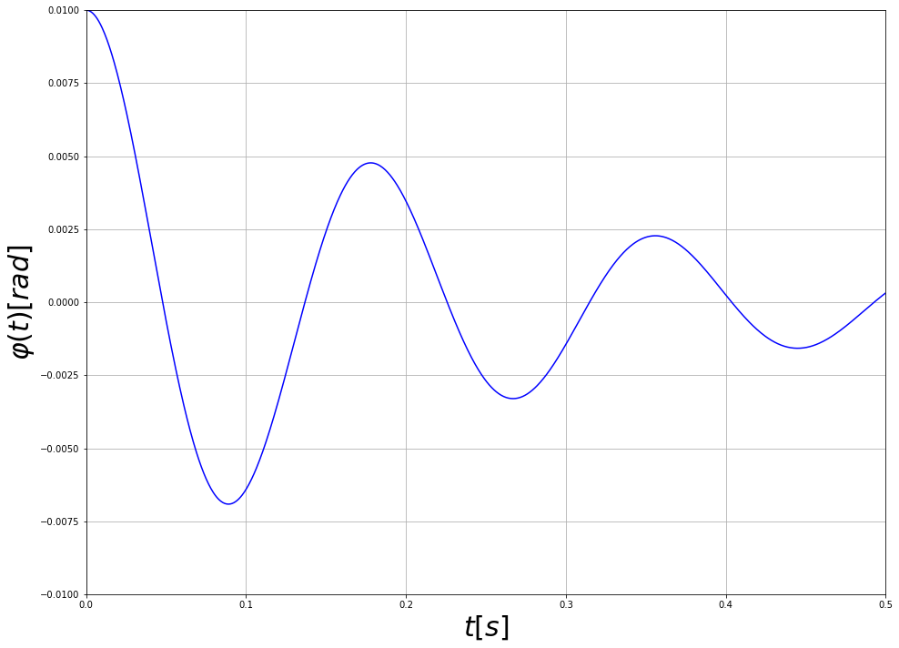

```python
# A matplotlib plottere az általunk megadott pontokat fogja egyenes vonalakkal összekötni.
# Elegendően kis lépésközt választva az így kapott görbe simának fog tűnni.
# Állítsuk elő az (x,y) koordinátákat!

t_val = np.linspace(0,0.5,1001) # lista létrehozása a [0 ; 0,5] intervallum 1001 részre való bontásával
φ_val = np.zeros(len(t_val)) # nulla lista létrehozása (ugyanannyi elemszámmal)
# for ciklus segítségével írjuk felül a nulla listában szerplő elemelet az adott x értékhez tartozó y értékekkel
for i in range(len(t_val)):
    φ_val[i] = mozg_torv.rhs.subs(t,t_val[i])  # Ezt lehetne list comprehension-nel is.


# rajzterület létrehozása
plt.figure(figsize=(40/2.54,30/2.54))

# függvény kirajzolása az x és y kordináta értékeket tartalmazó listák megadásásval
plt.plot(t_val,φ_val,color='b',label=r'num_sim')

# tengelyek
axes = plt.gca()
axes.set_xlim([0,t_val[-1]])
axes.set_ylim([-0.01, 0.01])

# rácsozás
plt.grid()

# tengely feliratozás
plt.xlabel(r'$ t [s] $',fontsize=30)
plt.ylabel(r'$ \varphi(t) [rad] $',fontsize=30)

plt.show()
```

A statikus rugóerő negatív előjelű, ezért két szélsőérték helyet is meg kell vizsgálni: az első lokális maximumot és a minimumot. Ezeket az értékekeket könnyen ki tudjuk szedni a korábban meghatározott listából.

```python
lok_max = max(φ_val)
lok_min = min(φ_val)

# Rugóerők meghatározása
Fr_11 = (Fr_1st_num+k1*3*l*φ_t).subs(adatok).subs(φ_t,lok_max).evalf(5)
Fr_12 = (Fr_1st_num+k1*3*l*φ_t).subs(adatok).subs(φ_t,lok_min).evalf(5)

display(Math('F_{{r,1}} = {}'.format(sp.latex(Fr_11))),Math('F_{{r,2}} = {}'.format(sp.latex(Fr_12))))

# [N]
```

$\displaystyle F_{r,1} = 0.0342$

$\displaystyle F_{r,2} = -3.0093$

A 1-es rugóban ébredő maximális erő tehát 3,009 N.

Készítette:

```
        Juhos-Kiss Álmos (Alkalmazott Mechanika Szakosztály)
        Takács Dénes (BME MM) ábrái és Vörös Illés (BME MM) kidolgozása alapján.

        Hibák, javaslatok:
        amsz.bme@gmail.com
        csuzdi02@gmail.com
        almosjuhoskiss@gmail.com

        2021.03.08
```